# Git, GitHub & Ocean Acidification

# **Task 7**

This task involves creating and resolving conflicts. Conflicts in files are denoted with specific markers. They look like this when you open a file with conflicts.

<<<<<<<<< HEAD

THIS IS YOUR CODE

[figure not shown]

```r
pathf <- "./data/pics/20220908210851.png"
fig <- readPNG(pathf)
figs <- comp_data %>%  filter(species==c("chromis","lemon","acantho"))%>%
  ggplot(aes(x = treatment, y = activity, fill = treatment)) +
  annotation_raster(fig,-Inf, Inf, 60, Inf)+
  geom_violin(trim = F) +
  facet_wrap(~species)+
  geom_boxplot(width = 0.45)+
  geom_jitter(aes(colour = treatment),size = 0.9,width=0.1,height=0)+
  theme_bw(base_size = 14)+ theme_bw(base_size = 12)+
  xlab('Species') + ylab('Activity (s)')+
  ggtitle("Box line plot of activity distribution for each species")+
  scale_fill_manual(values = c("#FCC7C3","#97E3AD","#BED7FF"))
figs
```

==============

THIS IS YOUR PARTNERS CODE <<<<<<< Updated upstream comp_data %>% filter(species == c(“chromis”,“lemon”,“acantho”)) %>% ggplot(aes(x = treatment, y = activity, fill = treatment)) + geom_violin(trim = F) +facet_wrap(~species)+ geom_boxplot(width = 0.45)+ geom_jitter(aes(colour = treatment),size = 0.9,width=0.1,height=0)+ theme_bw(base_size = 14)+ theme_bw(base_size = 12)+ xlab(‘Species’) + ylab(‘Activity (s)’)+ ggtitle(“Box line plot of activity distribution for each species”)+ scale_fill_manual(values = c(“#FCC7C3”,“#97E3AD”,“#BED7FF”)) =======

Resolving is easy. Decide on what changes you think are the best to proceed with and remove conflict markers.

> **Stretch Task**: Try creating another conflict in the `collabFig` code chunk of the Rmarkdown file. Resolve the conflict again. More practice doing this is always good!

Once you have figured out how to create and solve conflicts it’s time to update the README file with a little more detail about your project and the general workflow. The *GitHub* webpage uses the README file as a sort of introduction to the project.

**Task**: Provide details about the workflow (i.e., which files are used, when and why) and write a detailed description of the data file used. Include the details about what the column means and which data file someone should use.

Think about what you would need to know to make sure you can replicate a study. Provide these details so they are easy to find on the README.

# **Task 8**

There’s not too much to do in this task on the coding front! You just need to create a *GitHub* issue and create a ‘To Do’ list on *GitHub* for you and your collaborator.

# **Task 9**

Here, run some statistical tests to determine, for each species, whether the control vs high $CO^2$ treatments differ significantly from each other and in what direction. Provide the difference in means, their 95% confidence intervals, t-statistic, df and p-value.

> **Stretch Task**: You can of course do this for each species seperately, but those who want a challenge, think about how you might use a loop or even some wrangling methods you have already learnt from the tidyverse to run these tests across all 6 species in a single block of code. If you’re familiar with functions, you can even think about writing your own function! All these strategies will avoid having to copy and paste large chunks of code. If you’re repeating anything, writing functions and loops are good ways to simplify.

```r
# load dplyr and rstatix R package
library(dplyr)
library(rstatix)
# Run some statistical tests to determine for each species
slresult= Sp_Tr %>%
  group_by(species) %>%
  t_test(sl ~ treatment,detailed = TRUE)
actresult= Sp_Tr %>%
  group_by(species) %>%
  t_test(activity ~ treatment,detailed = TRUE)
# output result
result <- rbind(slresult,actresult)|>
convert_as_factor(.y., species)
result
```

| species factor | estimate numeric | estimate1 numeric | estimate2 numeric | .y. factor | group1 character | group2 character | n1 integer | n2 integer | statistic numeric | p numeric | df numeric | conf.low numeric | conf.high numeric | method character | alternative character |
| --- | --- | --- | --- | --- | --- | --- | --- | --- | --- | --- | --- | --- | --- | --- | --- |
| acantho | -1.2 | 18.4 | 19.6 | sl | CO2 | control | 86 | 90 | -0.5 | 0.6 | 174.0 | -6.5 | 4.1 | T-test | two.sided |
| ambon | -1.0 | 37.5 | 38.5 | sl | CO2 | control | 22 | 21 | -0.5 | 0.6 | 40.1 | -5.6 | 3.5 | T-test | two.sided |
| chromis | -1.5 | 32.0 | 33.4 | sl | CO2 | control | 14 | 20 | -0.4 | 0.7 | 21.7 | -9.2 | 6.2 | T-test | two.sided |
| humbug | -0.1 | 31.7 | 31.8 | sl | CO2 | control | 62 | 65 | -0.0 | 1.0 | 123.9 | -4.0 | 3.9 | T-test | two.sided |
| lemon | -0.0 | 28.8 | 28.8 | sl | CO2 | control | 19 | 30 | -0.0 | 1.0 | 44.0 | -2.5 | 2.5 | T-test | two.sided |
| whitedams | 0.5 | 14.5 | 14.0 | sl | CO2 | control | 60 | 61 | 0.4 | 0.7 | 119.0 | -2.2 | 3.3 | T-test | two.sided |
| acantho | -1.6 | 27.3 | 28.9 | activity | CO2 | control | 86 | 90 | -1.0 | 0.3 | 173.8 | -4.8 | 1.6 | T-test | two.sided |
| ambon | 1.1 | 18.4 | 17.3 | activity | CO2 | control | 22 | 21 | 0.3 | 0.8 | 41.0 | -6.2 | 8.3 | T-test | two.sided |
| chromis | -1.3 | 24.8 | 26.1 | activity | CO2 | control | 14 | 20 | -0.4 | 0.7 | 24.7 | -8.7 | 6.0 | T-test | two.sided |
| humbug | 5.4 | 40.3 | 34.9 | activity | CO2 | control | 62 | 65 | 2.3 | 0.0 | 123.7 | 0.8 | 9.9 | T-test | two.sided |

n: 12

```r
# Using the resulting object created above, which should be a table with all the summary statistics, t, df and p-value for each species create a table. Note that there is a tab.cap argument in the chunk arguments. Write a caption here.
table1 <- result|>
  convert_as_factor(.y., species) |>
  as_grouped_data(groups = c(".y."))|>
  flextable() |>
  separate_header() |>
  autofit() |>
  theme_booktabs(bold_header = TRUE) |>
  align(align = "center", part = "all", j = 1:16) |>
  merge_v(j = 1) |>
  valign(j = 1, valign = "top") |>
  colformat_double(digits = 2)|>
  autofit()
table1
```

Table 1: t statistical tests to determine for each species

| y | species | estimate | estimate1 | estimate2 | group1 | group2 | n1 | n2 | statistic | p | df | conf low | conf high | method | alternative |  |  |
| --- | --- | --- | --- | --- | --- | --- | --- | --- | --- | --- | --- | --- | --- | --- | --- | --- | --- |
| sl |  |  |  |  |  |  |  |  |  |  |  |  |  |  |  |  |  |
|  | acantho | -1.23 | 18.39 | 19.62 | CO2 | control | 86 | 90 | -0.46 | 0.65 | 173.96 | -6.51 | 4.05 | T-test | two.sided |  |  |
|  | ambon | -1.04 | 37.47 | 38.50 | CO2 | control | 22 | 21 | -0.46 | 0.65 | 40.08 | -5.56 | 3.49 | T-test | two.sided |  |  |
|  | chromis | -1.48 | 31.95 | 33.43 | CO2 | control | 14 | 20 | -0.40 | 0.69 | 21.74 | -9.16 | 6.21 | T-test | two.sided |  |  |
|  | humbug | -0.09 | 31.69 | 31.77 | CO2 | control | 62 | 65 | -0.04 | 0.96 | 123.91 | -4.04 | 3.86 | T-test | two.sided |  |  |
|  | lemon | -0.03 | 28.82 | 28.85 | CO2 | control | 19 | 30 | -0.02 | 0.98 | 43.97 | -2.54 | 2.48 | T-test | two.sided |  |  |
|  | whitedams | 0.51 | 14.47 | 13.97 | CO2 | control | 60 | 61 | 0.37 | 0.72 | 118.99 | -2.25 | 3.26 | T-test | two.sided |  |  |
| activity |  |  |  |  |  |  |  |  |  |  |  |  |  |  |  |  |  |
|  | acantho | -1.63 | 27.30 | 28.93 | CO2 | control | 86 | 90 | -1.00 | 0.32 | 173.83 | -4.85 | 1.60 | T-test | two.sided |  |  |
|  | ambon | 1.05 | 18.39 | 17.34 | CO2 | control | 22 | 21 | 0.29 | 0.77 | 40.99 | -6.23 | 8.34 | T-test | two.sided |  |  |
|  | chromis | -1.32 | 24.78 | 26.10 | CO2 | control | 14 | 20 | -0.37 | 0.71 | 24.67 | -8.68 | 6.04 | T-test | two.sided |  |  |
|  | humbug | 5.37 | 40.28 | 34.92 | CO2 | control | 62 | 65 | 2.34 | 0.02 | 123.68 | 0.83 | 9.90 | T-test | two.sided |  |  |
|  | lemon | 6.24 | 26.04 | 19.80 | CO2 | control | 19 | 30 | 1.86 | 0.07 | 41.61 | -0.55 | 13.04 | T-test | two.sided |  |  |
|  | whitedams | -2.13 | 24.46 | 26.59 | CO2 | control | 60 | 61 | -1.12 | 0.26 | 118.29 | -5.89 | 1.63 | T-test | two.sided |  |  |

Now that you have a table, you can reference it within a document. For example, you can make a call to Table 1 by referring to the name of the code chunk. When you knit the html it will create a hyperlink to your table and insert a legend above the table for you. How cool is that!?

> **Question 8**: Pick one of your favorite species and write about the results to a reader. Write in the Rmarkdown file below what 1) the means and mean differences between control and acidification treatment is along with 2) the 95% confidence intervals of the difference
> 1. In humbug species, the mean values of standard length in fish for control and acidified treatment groups were 31.77 mm and 31.69 mm, respectively, with a mean difference of 0.09. The mean values of activity in fish were 34.92 (s / min) and 40.28 (s / min), respectively, with a mean difference of 5.37 (s / min). In humbug species, the mean values of standard length in fish for control and acidified treatment groups were 31.77 mm and 31.69 mm, respectively, with a mean difference of 0.09 mm.
> 2. The 95% confidence intervals for the differences ranged from -4.04 to 3.86 for the standard length of the fish and 0.83 to 9.90 for the activity of the fish.

You can write your blurb below this. Before you do that, a few cool features of Rmarkdown. You can actually code in objects so that, when they are rendered they replace the inline code chunk with the result. To give you an example, an inline code chunk is written as follows: add code here. When you render the document, whatever you place in the “add code here” section will be rendered. In this case, we are giving a string, so it simply just adds that in the place where the code is, render and see for yourself.

Moving forward on that you can also add in an object and whatever that objects value is will also be spit out. For example, consider the following: 10. What will happen? Well, it will place in the value 10 when rendered. Again, if you don’t believe me, check for yourself by rendering the document.

This is all **VERY** cool because that means if your code or data change than you can update your entire report very fast. It’s also 100% reproducible. We know exactly where every single value in your report comes from. This is all pretty helpful when you want to check your code and report side-by-side. Now that you have a bit more detail fill in the following:

Mean activity for humbug in the control group was 34.92 (s / min) compared to the OA treatment group, which was 40.28 (s / min). The difference between control and OA treatment means was 5.37 (s / min) (95% CI: 0.83 to 9.9).

Now, using what you just learnt, describe what the null hypothesis being tested was and provide statistical evidence (t-statistic, df, and p-value) to support your conclusion about whether we can reject the null hypothesis. Again, make sure you use in-line code. Write you answer below:

**Write your answer here** The null hypothesis being tested is that the mean activity of humbug species is not statistically significantly different in the control and OA treatment groups. Based on the results of the t-test: t-statistic of 2.34, df of 123.68 and p-value of 0.02 less than α = 0.05, the null hypothesis was rejected and the alternative hypothesis that the mean activity of the humbug species was statistically significantly different between the control and OA treatment groups was accepted (significant level α = 0.05).

Re-analyse the data for a single species using permutations instead of a t-test. Do your results differ?

> **Stretch Task**: If you really want a challenge try doing permutation tests for each species. Again, loops, functions or tidyverse (or even combinations might help).

```r
#
comp_data
```

| loc character | species character | treatment character | animal_id numeric | sl numeric | size character | activity numeric | comment character |
| --- | --- | --- | --- | --- | --- | --- | --- |
| LIRS 2014 | ambon | CO2 | 64 | 57.0 | big | 8.1 | 27min means of sml+lrg dur, from All Lizard activity data for JJ v2_7 Jun 2017.xlsx |
| LIRS 2014 | ambon | CO2 | 65 | 38.2 | big | 10.5 | 27min means of sml+lrg dur, from All Lizard activity data for JJ v2_7 Jun 2017.xlsx |
| LIRS 2014 | ambon | CO2 | 67 | 39.3 | big | 6.5 | 27min means of sml+lrg dur, from All Lizard activity data for JJ v2_7 Jun 2017.xlsx |
| LIRS 2014 | ambon | CO2 | 68 | 36.1 | big | 27.8 | 27min means of sml+lrg dur, from All Lizard activity data for JJ v2_7 Jun 2017.xlsx |
| LIRS 2014 | lemon | CO2 | 74 | 36.4 | big | 36.7 | 27min means of sml+lrg dur, from All Lizard activity data for JJ v2_7 Jun 2017.xlsx |
| LIRS 2014 | ambon | CO2 | 75 | 35.9 | big | 42.8 | 27min means of sml+lrg dur, from All Lizard activity data for JJ v2_7 Jun 2017.xlsx |
| LIRS 2014 | lemon | CO2 | 81 | 35.7 | big | 21.9 | 27min means of sml+lrg dur, from All Lizard activity data for JJ v2_7 Jun 2017.xlsx |
| LIRS 2014 | ambon | CO2 | 84 | 38.4 | big | 24.6 | 27min means of sml+lrg dur, from All Lizard activity data for JJ v2_7 Jun 2017.xlsx |
| LIRS 2014 | ambon | CO2 | 85 | 48.3 | big | 35.1 | 27min means of sml+lrg dur, from All Lizard activity data for JJ v2_7 Jun 2017.xlsx |
| LIRS 2014 | ambon | CO2 | 88 | 43.4 | big | 1.0 | 27min means of sml+lrg dur, from All Lizard activity data for JJ v2_7 Jun 2017.xlsx |

n: 550

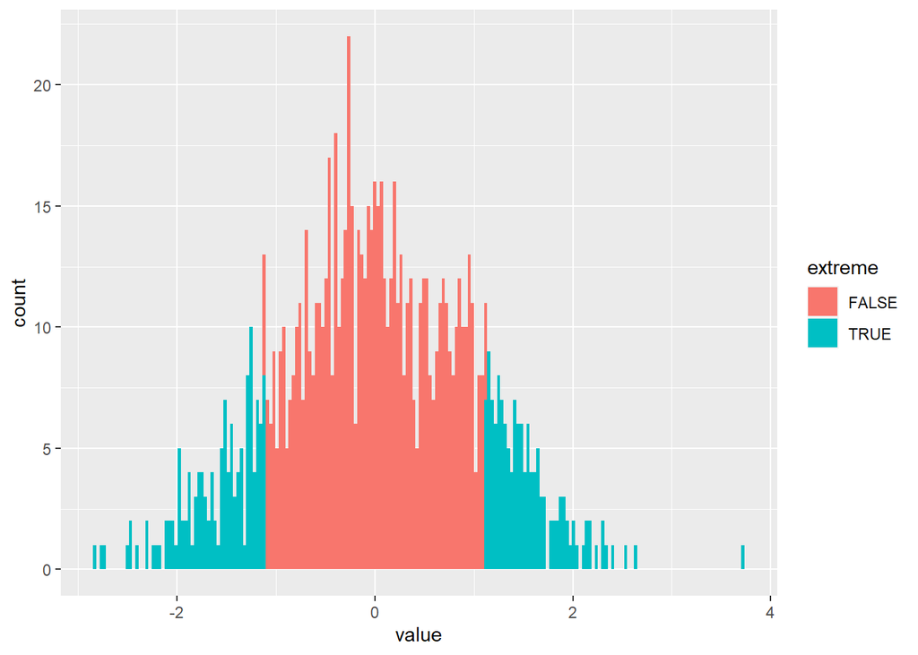

```r
# Set the number of reps
n_reps <- 1000
permutation_result <- tibble()
for (i in unique(comp_data$species)){
# Create a vector to store the results
samp_dist <- rep(0,n_reps)
   selected_data <- comp_data[which(comp_data$species == i),]
   for (j in 1:n_reps){
    # Perform t-test on new permuted group data
     permuted_t_test_results <- selected_data %>% mutate(treatment = treatment[sample(row_number())]) %>%
         t.test(activity ~ treatment, data = .)
    # Store the result data for each randomization
     samp_dist[j] <-permuted_t_test_results$statistic
   }

   t_value <- comp_data[which(comp_data$species == i),] %>% t.test(activity ~ treatment, data = .) %>% .$statistic
   permutation_pvalue <- permuted_t_test_results$p.value
   permutation_result <- rbind(permutation_result, tibble(species = i,P_value = permutation_pvalue))
   # Of the 10,000 (n_reps) random t-statistics generated from the sampling distribution that meet the null hypothesis, identify values that are more extreme than those calculated for our original data and store logical (TRUE/FALSE) results  in tibble
   plot_tibble <- tibble(value = samp_dist,extreme = (abs(samp_dist) > abs(t_value)))
  # Create a histogram in ggplot
   fig <- ggplot(plot_tibble,aes(x=value,fill=extreme))+geom_histogram(bins=200)

}
fig
```

```r
permutation_result
```

| species character | P_value numeric |
| --- | --- |
| ambon | 0.1 |
| lemon | 0.3 |
| chromis | 0.7 |
| acantho | 0.5 |
| humbug | 0.4 |
| whitedams | 0.2 |

```r
stat_result <- full_join(actresult,permutation_result)
stat_result
```

| species character | estimate numeric | estimate1 numeric | estimate2 numeric | .y. character | group1 character | group2 character | n1 integer | n2 integer | statistic numeric | p numeric | df numeric | conf.low numeric | conf.high numeric | method character | alternative character | P_value numeric |
| --- | --- | --- | --- | --- | --- | --- | --- | --- | --- | --- | --- | --- | --- | --- | --- | --- |
| acantho | -1.6 | 27.3 | 28.9 | activity | CO2 | control | 86 | 90 | -1.0 | 0.3 | 173.8 | -4.8 | 1.6 | T-test | two.sided | 0.5 |
| ambon | 1.1 | 18.4 | 17.3 | activity | CO2 | control | 22 | 21 | 0.3 | 0.8 | 41.0 | -6.2 | 8.3 | T-test | two.sided | 0.1 |
| chromis | -1.3 | 24.8 | 26.1 | activity | CO2 | control | 14 | 20 | -0.4 | 0.7 | 24.7 | -8.7 | 6.0 | T-test | two.sided | 0.7 |
| humbug | 5.4 | 40.3 | 34.9 | activity | CO2 | control | 62 | 65 | 2.3 | 0.0 | 123.7 | 0.8 | 9.9 | T-test | two.sided | 0.4 |
| lemon | 6.2 | 26.0 | 19.8 | activity | CO2 | control | 19 | 30 | 1.9 | 0.1 | 41.6 | -0.5 | 13.0 | T-test | two.sided | 0.3 |
| whitedams | -2.1 | 24.5 | 26.6 | activity | CO2 | control | 60 | 61 | -1.1 | 0.3 | 118.3 | -5.9 | 1.6 | T-test | two.sided | 0.2 |

Below. Add a few sentences for the species (or multiple species) you talked about above to describe the permutation results:

# **Task 10**

This is a stretch task on the use of *GitHub* and the challenges (or maybe lack of challenges) of reproducing others’ work. If you finish the above tasks, then, have a crack at this one. See the html for details.